# Data Scraping-part1

10/30/2017

## General idea

### **Data scraping/web scraping**

- Crawling
- Extraction: parsing, searching, reformatting…

[figure not shown]

  Icon made by Freepik from http://www.flaticon.com

## What is an API

- **A**pplication **P**rogramming **I**nterface
  - a way for software to communicate each other
  - restaurant example

## What is an API

- Web APIs
  - APIs for either web browser or web server
  - Twitter API, Google API, FB API…
  - Expedia example

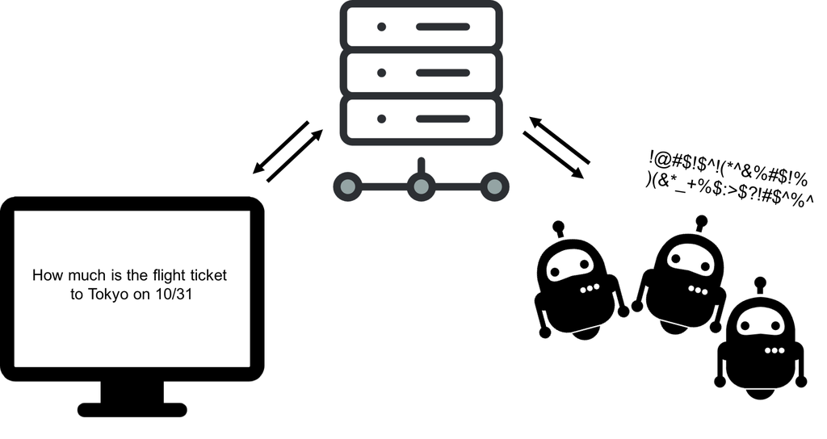

## Using APIs with R

- Using R packages for interacting with specific APIs
  - **twitteR, Rfacebook**, googleAuthR, googleAnalyticsR…
- Directly using R
  - **google map**

## Getting data from Twitter

- Getting credentials: consumer key & secret, access token & token secret
  - set up Twitter developer account https://apps.twitter.com/

[figure not shown]

## Getting data from Twitter

- Getting credentials: consumer key & secret, access token & token secret
  - set up Twitter developer account https://apps.twitter.com/
  - Create New App

[figure not shown]

## Getting data from Twitter

- Getting credentials: consumer key & secret, access token & token secret
  - set up Twitter developer account https://apps.twitter.com/
  - Create New App
  - Keys and Access Tokens

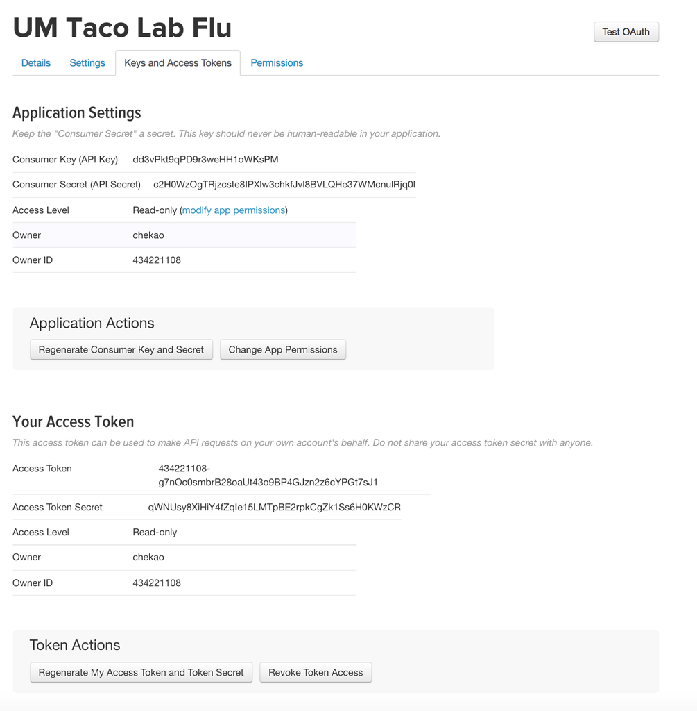

## Getting data from Twitter

### **install [twitterR](https://www.rdocumentation.org/packages/twitteR/versions/1.1.9)**

```r
library(twitteR)
consumer_key <- "dd3vPkt9qPD9r3weHH1oWKsPM"
consumer_secret <- "c2H0WzOgTRjzcste8IPXlw3chkfJvl8BVLQHe37WMcnulRjq0l"
access_token <- "434221108-g7nOc0smbrB28oaUt43o9BP4GJzn2z6cYPGt7sJ1"
access_secret <- "qWNUsy8XiHiY4fZqIe15LMTpBE2rpkCgZk1Ss6H0KWzCR"
setup_twitter_oauth(consumer_key, consumer_secret, access_token, access_secret)
```

## Getting data from Twitter

### **following/follower example**

```r
seed_user <- getUser('@chekao')
seed_user$getFollowerIDs()

tweets<-searchTwitter('vaccines AND autism', n=3)
target_users<-sapply(tweets, function(x) x$screenName)
target_tweets<-sapply(tweets, function(x) x$getId())
#retweet related functions are buggy, need to report

for (f in 1:length(target_tweets)){
  temp_name<-paste("@", target_users[f], sep="")
  temp_seed<-getUser(temp_name)
  temp_location<-temp_seed$getLocation()
  temp_followers<-try(temp_seed$getFollowerIDs())
  assign(paste(target_users[f],target_tweets[f],sep="_"),c(temp_seed, temp_location, temp_followers))
}

# try different search operators (check twitter search)
```

## Getting data from FB

- Getting credentials: consumer key & secret, access token & token secret
  - Creating an App https://developers.facebook.com/
  - Note: need to fill in the redirect url in fb log-in
  - can only get very limited data (from users who are using the app)

```r
library(Rfacebook)
fb_oauth <- fbOAuth(
  app_id="1596159733760349",
  app_secret="80ed4ac9263f22825fcb9e75c4138c67",
  extended_permissions = TRUE)

save(fb_oauth, file="token") #next time you can just load the token
#load("token")
```

## Getting data from FB

- Getting credentials: consumer key & secret, access token & token secret
  - Creating an App https://developers.facebook.com/
  - Note: need to fill in the redirect url in fb log-in
  - can only get very limited data (from users who are using the app)

```r
getUsers("me",token=fb_oauth) #public profile
head(getLikes(user="me", token=fb_oauth)) #likes
updateStatus("hiho", fb_oauth) #fb post via R
#yhk_friends <- getFriends(fb_oauth, simplify = TRUE) #get friends who are using the app
```

## Getting data from FB

- Getting credentials: consumer key & secret, access token & token secret
  - Creating a temporary token through https://developers.facebook.com/
  - Less restrictions
  - Only for 2 hrs

```r
library(Rfacebook)
fb_oauth <- "EAACEdEose0cBAHq5BckCFOiiF7SWtZC9Jsbc21jVHMLUBp4hvRX5zt7aEx9JcEFQlSN85BBGps0VSQvXzaZAZBvwTUQqaIugV6K72UdZAZCRb6WEBtinDhUgJDkXOHMMEXGGQaPHYUonZATjz1umv2W4ZBAqaaSfdAsAtY2ppyyWF4lO11avbGnGLFpYz5WgcEZD"
getUsers("me",token=fb_oauth) #public profile
head(getLikes(user="me", token=fb_oauth)) #likes
updateStatus("hiho", fb_oauth) #fb post via R
yhk_friends <- getFriends(fb_oauth, simplify = TRUE)
```

## Getting data from FB

- Getting credentials: consumer key & secret, access token & token secret
  - Creating a temporary token through https://developers.facebook.com/tools/explorer/
  - Less restrictions
  - Only for 2 hrs

```r
pages<-getPage("DonaldTrump",fb_oauth,n=5)
target_post<-getPost(pages$id[1], fb_oauth, n=100, likes = TRUE, comments = FALSE)
target_user<-getUsers(target_post$likes$from_id, fb_oauth)
```

## Getting data from google maps

```r
# adapted the script from Jose Gonzalez
library(RCurl)
library(RJSONIO)

#write query
query_url<- function(address, return.call = "json", sensor = "false") {
  root <- "http://maps.google.com/maps/api/geocode/"
  u <- paste(root, return.call, "?address=", address, "&sensor=", sensor, sep = "")
  return(URLencode(u))
}
```

## Getting data from google maps

```r
#get and parse json result
geoCode <- function(address,verbose=FALSE) {
  if(verbose) cat(address,"\n")
  u <- query_url(address)
  doc <- getURL(u)
  x <- fromJSON(doc,simplify = FALSE)
  if(x$status=="OK") {
    lat <- x$results[[1]]$geometry$location$lat
    lng <- x$results[[1]]$geometry$location$lng
    location_type  <- x$results[[1]]$geometry$location_type
    formatted_address  <- x$results[[1]]$formatted_address
    return(c(lat, lng, location_type, formatted_address))
    Sys.sleep(0.5)
  } else {
    return(c(NA,NA,NA, NA))
  }
}
```

## Getting data from google maps

```r
# adapted the script from Jose Gonzalez
library(ggmap)
target_loc <- geoCode("ann arbor sph")
sphmap <- get_map(location = c(lon = as.numeric(target_loc[2]),
                  lat = as.numeric(target_loc[1])), zoom = 10,
                  maptype = "roadmap", scale = 2)
```

## Other ways to use APIs

- Python: have very comprehensive libraries (lots of them are directly developed by the companies)
- Your browser: try http://maps.googleapis.com/maps/api/geocode/json
- Online platforms: try [apigee for twitter](https://apigee.com/console/twitter)

## Ethics

- Be nice to people…
- Don't make evil bots
- Ask data nicely

## Data scraping without APIs

- View page source and inspect
- Simple html: Rcurl + xml or/and RJSONIO
- Somewhat complicated html, or need to do some additional requests (eg. get, post, etc): rvest (scrapeR)
- Fancy websites: rvest+Rselenium

## Data scraping without APIs

- View page source and inspect
- Simple html: Rcurl + xml or/and RJSONIO
- Somewhat complicated html, or need to do some additional requests (eg. get, post, etc): rvest (scrapeR)
- Fancy websites: rvest+Rselenium

  **More on Wednesday**